# Filter/joins (like VLOOKUP in Excel)

Whitney

12/8/2019

## Attach packages

Read in 3 files:

- invert_counts_curated.xlsx
- fish_counts_curated.csv
- kelp_counts_curated.xlsx

```r
invert_counts <- read_excel(here("R-workshop-data", "invert_counts_curated.xlsx"))
fish_counts <- read_csv(here("R-workshop-data", "fish_counts_curated.csv"))
kelp_count_abur <- read_excel(here("R-workshop-data", "kelp_counts_curated.xlsx"))
```

filter based off a condition you are setting by selecting only certain observations ##Filter to match rows based on a character string

Only keep observations from fish_counts where the common_name variable matches “garibaldi”

```r
fish_garibaldi <- fish_counts %>%
  filter(common_name == "garibaldi")

# Use janitor::clean_names() to automatically update all of your column names to lowercase_snake_case
```

Filter to keep/exclude observations based on conditions

```r
fish_over50 <- fish_counts %>%
  filter(total_count >= 50)
```

Create a subset that only contains observations for sih at Mohawk Reef (“mohk”)

```r
fish_mohk <- fish_counts %>%
  filter(site == "mohk")
```

##Filter to keep rows that match THIS or THAT

#We want to keep any observations for garibaldi, blacksmith, or black surfperch

```r
 fish_3sp <- fish_counts %>%
   filter(common_name %in% c("garibaldi", "blacksmith", "black surfperch"))
```

filter defaults to include multiple items as “OR” with %in% and concatanating the list of options

## Filter to return that match conditions for MULTIPLE variables (AND statements)

I want to create a subset called urchin_abur_mohk that only keeps observations where site is: - site is “abur” or “mohk” AND - species is “purple urchin”

seperate “AND” conditions within a single filter line and comma

```r
urchin_abur_mohk <- invert_counts %>%
  filter(site %in% c ("abur", "mohk"), common_name == "purple urchin")
```

Activity Create a subset from fish_counts, called low_gb_rw that only contains observations for “garibaldi” and “rock wrasse” where to total count is less than 10

```r
low_gb_rw <- fish_counts %>%
  filter(common_name %in% c("garibaldi", "rock wrasse")) %>%
  filter(total_count < 10)
```

Filter rows that do not match conditions, use != which means does not match

Try to create a subset from fish_counts that does NOT contain observations for Mohawk Reef

```r
fish_no_mohawk <- fish_counts %>%
  filter(site != "mohk")
```

An example of filter as part of a piped sequence:

```r
senorita_all_years <- fish_counts %>%
  filter(common_name =="senorita") %>%
  group_by(site) %>%
  summarize(count_all_years = sum(total_count))
```

## A couple ways of joining data frames

- `full_join()`: keeps everything (safe join)
- `left_join()`: If we are merging A and B, will only retain the observations from B that have matches in A

```r
fish_2016_2017 <- fish_counts %>%
  filter(year == 2016 | year ==2017)
```

```r
kelp_count_abur <- kelp_count_abur %>%
  mutate(year = as.numeric(year))

class(kelp_count_abur$year)
```

```
## [1] "numeric"
```

Now we can join them:

```r
abur_kelp_join <- fish_2016_2017 %>%
  full_join(kelp_count_abur, by = c("year", "site"))
```

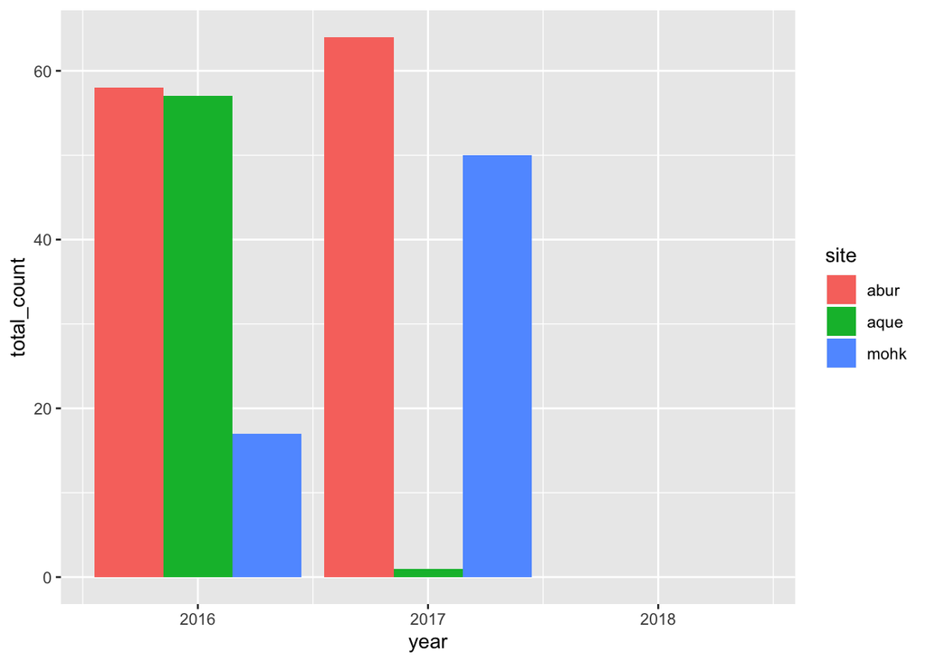

```r
ggplot(abur_kelp_join, aes(x = year, y = total_count))+
  geom_col(aes(fill= site), position = "dodge")
```